```python
import numpy as np
import matplotlib.pyplot as plt
%matplotlib inline
from scipy import stats
import pandas as pd
import statsmodels.api as sm
from statsmodels.formula.api import ols
```

# Part1

```python
df= pd.read_excel('data.xlsx')
```

```python
df.head()
```

|  | Close_ETF | oil | gold | JPM |
| --- | --- | --- | --- | --- |
| 0 | 97.349998 | 0.039242 | 0.004668 | 0.032258 |
| 1 | 97.750000 | 0.001953 | -0.001366 | -0.002948 |
| 2 | 99.160004 | -0.031514 | -0.007937 | 0.025724 |
| 3 | 99.650002 | 0.034552 | 0.014621 | 0.011819 |
| 4 | 99.260002 | 0.013619 | -0.011419 | 0.000855 |

```python
print(df.mean())
print(df.std())
print(df.corr())
```

```
Close_ETF    121.152960
oil            0.001030
gold           0.000663
JPM            0.000530
dtype: float64
Close_ETF    12.569790
oil           0.021093
gold          0.011289
JPM           0.011017
dtype: float64
           Close_ETF       oil      gold       JPM
Close_ETF   1.000000 -0.009045  0.022996  0.036807
oil        -0.009045  1.000000  0.235650 -0.120849
gold        0.022996  0.235650  1.000000  0.100170
JPM         0.036807 -0.120849  0.100170  1.000000
```

# Part2

·Histogram

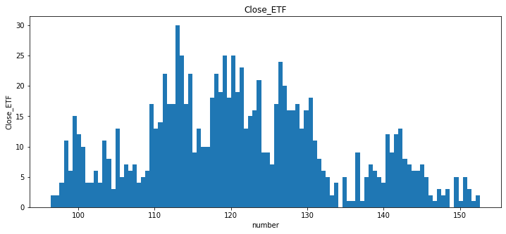

```python
plt.figure(figsize=(12, 5))
plt.hist(df["Close_ETF"], bins=100)
plt.title('Close_ETF')
plt.xlabel('number')
plt.ylabel('Close_ETF')
plt.show()
```

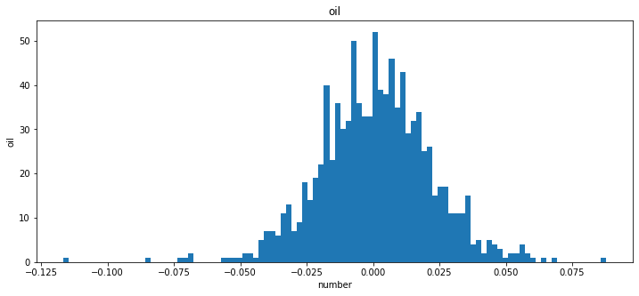

```python
plt.figure(figsize=(12, 5))
plt.hist(df["oil"], bins=100)
plt.title('oil')
plt.xlabel('number')
plt.ylabel('oil')
plt.show()
```

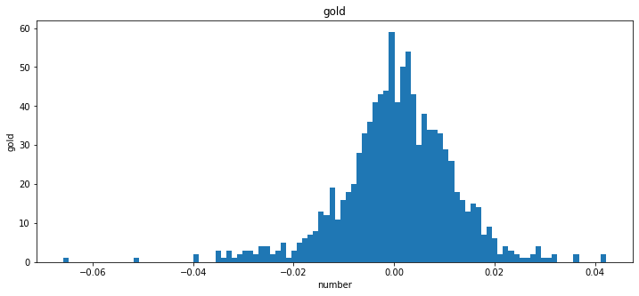

```python
plt.figure(figsize=(12, 5))
plt.hist(df["gold"], bins=100)
plt.title('gold')
plt.xlabel('number')
plt.ylabel('gold')
plt.show()
```

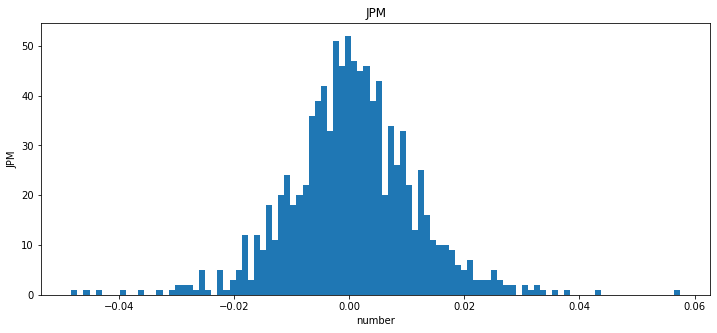

```python
plt.figure(figsize=(12, 5))
plt.hist(df["JPM"], bins=100)
plt.title('JPM')
plt.xlabel('number')
plt.ylabel('JPM')
plt.show()
```

·Time series plot(each)

```python
time=list(range(0,1000))
```

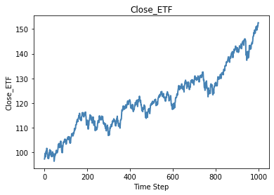

```python
plt.plot(time, # x axis
         df.Close_ETF, # y axis
         linestyle = '-',
         linewidth = 2,
         color = 'steelblue')

plt.title('Close_ETF')
plt.xlabel('Time Step')
plt.ylabel('Close_ETF')
plt.show()
```

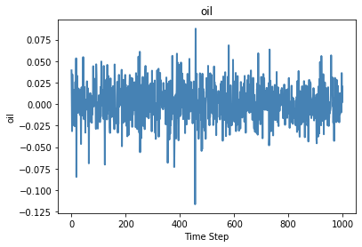

```python
plt.plot(time, # x axis
         df.oil, # y axis
         linestyle = '-',
         linewidth = 2,
         color = 'steelblue')

plt.title('oil')
plt.xlabel('Time Step')
plt.ylabel('oil')
plt.show()
```

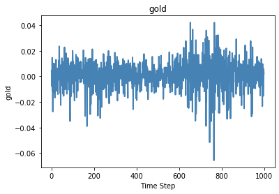

```python
plt.plot(time, # x axis
         df.gold, # y axis
         linestyle = '-',
         linewidth = 2,
         color = 'steelblue')

plt.title('gold')
plt.xlabel('Time Step')
plt.ylabel('gold')
plt.show()
```

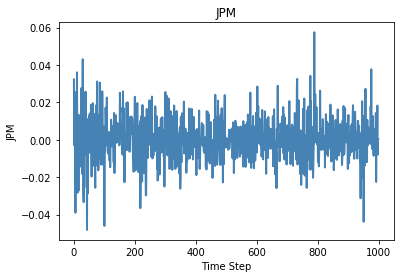

```python
plt.plot(time, # x axis
         df.JPM, # y axis
         linestyle = '-',
         linewidth = 2,
         color = 'steelblue')

plt.title('JPM')
plt.xlabel('Time Step')
plt.ylabel('JPM')
plt.show()
```

·Time series plot for all four columns

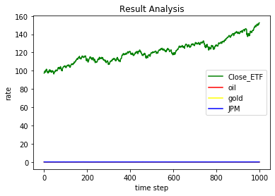

```python
plt.title('Result Analysis')


plt.plot(time, df.Close_ETF, color='green', label='Close_ETF')
plt.plot(time, df.oil, color='red', label='oil')
plt.plot(time, df.gold,  color='yellow', label='gold')
plt.plot(time, df.JPM, color='blue', label='JPM')
plt.legend()

plt.xlabel('time step')
plt.ylabel('rate')
plt.show()
```

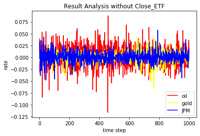

```python
plt.title('Result Analysis without Close_ETF')
plt.plot(time, df.oil, color='red', label='oil')
plt.plot(time, df.gold,  color='yellow', label='gold')
plt.plot(time, df.JPM, color='blue', label='JPM')
plt.legend()

plt.xlabel('time step')
plt.ylabel('rate')
plt.show()
```

Scatter plots:

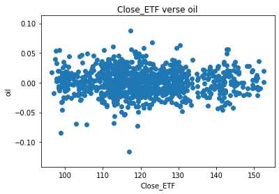

```python
plt.scatter(df.Close_ETF,df.oil)
plt.title('Close_ETF verse oil')
plt.xlabel('Close_ETF')
plt.ylabel('oil')
plt.show()
```

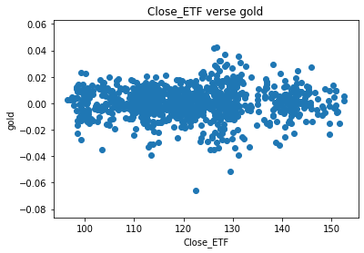

```python
plt.scatter(df.Close_ETF,df.gold)
plt.title('Close_ETF verse gold')
plt.xlabel('Close_ETF')
plt.ylabel('gold')
plt.show()
```

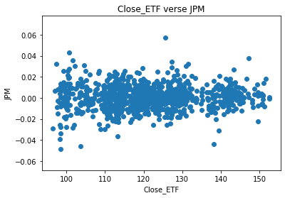

```python
plt.scatter(df.Close_ETF,df.JPM)
plt.title('Close_ETF verse JPM')
plt.xlabel('Close_ETF')
plt.ylabel('JPM')
plt.show()
```

# Part 3: What distribution does your data follow

Suppose Close_ETF follows uniform distribution.

```
KstestResult(statistic=0.9373134433134432, pvalue=0.0)
```

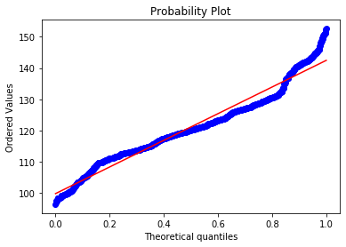

```python
print(stats.kstest(df.oil, 'uniform'))
stats.probplot(df.Close_ETF, dist='uniform', plot=plt)
plt.show()
```

Suppose oil follows normal distribution.

```
KstestResult(statistic=0.4727185265212217, pvalue=1.2565304659417615e-205)
```

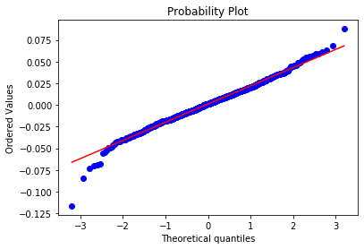

```python
print(stats.kstest(df.oil, 'norm'))
stats.probplot(df.oil, dist="norm", plot=plt)
plt.show()
```

Although from Part 2, oil colum looks somehow follow normal distribution. But through the qq plot, we can see this is not the case. Also, the pvalue of Kolmogorov-Smirnov test is less than 0.05, which also shows that these data soesn't follow normal distribution.

Suppose gold follows normal distribution.

```
KstestResult(statistic=0.48333847934283236, pvalue=1.4922487931964242e-215)
```

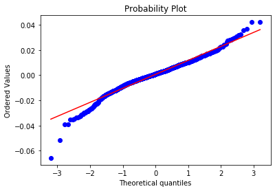

```python
print(stats.kstest(df.gold, 'norm'))
stats.probplot(df.gold, dist="norm", plot=plt)
plt.show()
```

Although from Part 2, gold colum looks somehow follow normal distribution. But through the qq plot, we can see this is not the case. Also, the pvalue of Kolmogorov-Smirnov test is less than 0.05, which also shows that these data soesn't follow normal distribution.

Suppose JPM follows normal distribution.

```
KstestResult(statistic=0.4829776270752645, pvalue=3.278870501508125e-215)
```

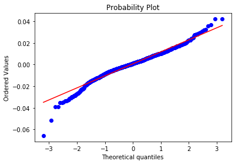

```python
print(stats.kstest(df.JPM, 'norm'))
stats.probplot(df.gold, dist="norm", plot=plt)
plt.show()
```